# DS202: Lab 5

MyTien Kien; kmytien

4/11/2021

```r
library(ggplot2)
library(tidyr)
library(classdata)
library(lubridate)
library(dplyr)
library(maps)

accident <- read.csv("https://raw.githubusercontent.com/xdaiISU/ds202materials/master/hwlabs/fars2017/accident.csv", stringsAsFactors = FALSE)

person <- read.csv("https://raw.githubusercontent.com/xdaiISU/ds202materials/master/hwlabs/fars2017/person.csv", stringsAsFactors = FALSE)
```

## **Questions**

**1. Are there some days of the week where more accidents happen than the others (see FARS manual, use variable DAY_WEEK)?**

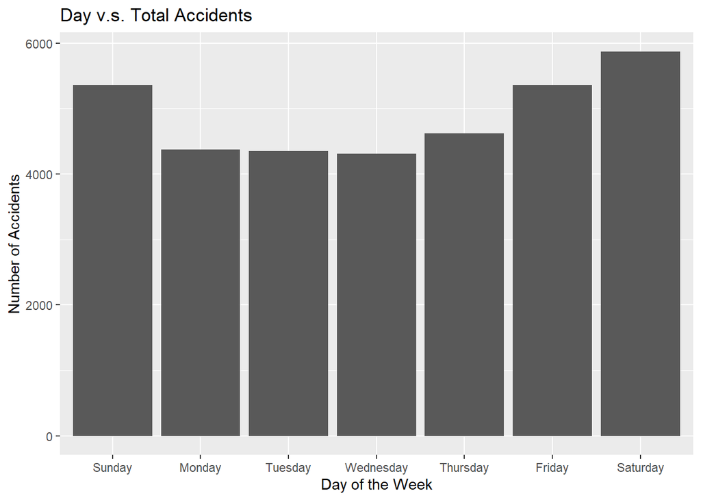

```r
q1 <- accident %>%
      group_by(DAY_WEEK) %>%
      summarise(Accidents = n()) %>%
      mutate(DAY_WEEK = as.factor(DAY_WEEK))

ggplot(q1, aes(x = DAY_WEEK, y = Accidents)) + geom_bar(stat = 'identity') +
      scale_x_discrete(labels = c('Sunday', 'Monday', 'Tuesday', 'Wednesday', 'Thursday', 'Friday', 'Saturday')) +
      ggtitle("Day v.s. Total Accidents") + xlab("Day of the Week") + ylab("Number of Accidents")
```

Shown here, it seems that the weekend days, Friday, Saturday and Sunday, are the most common days to get in an accident. This could be for many reasons as most people are off work and plan to go out of town, people like to drink on the weekends, and so on.

**2. Create a data frame containing the persons who are fatally hurt in the accidents (look up variable INJ_SEV)**

```r
q2 <- person %>% filter(INJ_SEV == 4)
head(q2)
```

```
##   STATE ST_CASE VE_FORMS VEH_NO PER_NO STR_VEH COUNTY DAY MONTH HOUR MINUTE
## 1     1   10001        1      1      1       0     73  19     2   23     35
## 2     1   10002        1      1      1       0     89  14     2   14     59
## 3     1   10003        3      2      1       0    101  31     1   20     31
## 4     1   10004        1      1      1       0     73   1     1   16     55
## 5     1   10005        1      1      1       0     13   1     1   20      0
## 6     1   10006        2      1      1       0     49   6     1   18     40
##   RUR_URB FUNC_SYS HARM_EV MAN_COLL SCH_BUS MAKE MAK_MOD BODY_TYP MOD_YEAR
## 1       2        1      38        0       0   20   20421       15     2004
## 2       2        1       1        0       0   37   37402       14     2005
## 3       2        1      12        1       0    2    2404       14     2003
## 4       2        4      30        0       0   30   30046        4     2014
## 5       1        1      35        0       0   12   12471       34     2010
## 6       1        1      34        0       0   49   49032        4     1997
##   TOW_VEH SPEC_USE EMER_USE ROLLOVER IMPACT1 FIRE_EXP AGE SEX PER_TYP INJ_SEV
```

[output cut: 41 more lines]

Looking in the FARS manual, I found that a Fatal Injury is represented as the number 4 in “INJ_SEV”. With that, I used filter to filter the data so it only shows records of those who had a fatal injury.

**3. Create a data frame containing the most dangerous vehicle make in each state. The number of persons fatally hit in the vehicle make is used to assess the (non-)safety of a make. Make sure to handle the missing values appropriately. (look up variable MAKE)**

```r
q3 <- person %>%
      filter(INJ_SEV == 4) %>%
      group_by(STATE, MAKE) %>%
      summarise(Accidents = n()) %>%
      filter(Accidents == max(Accidents))

q3 <- drop_na(q3)
q3
```

```
## # A tibble: 24 x 3
## # Groups:   STATE [23]
##    STATE  MAKE Accidents
##    <int> <int>     <int>
##  1     1    12       138
##  2     5    20        88
##  3    15    49        21
##  4    16    12        35
##  5    18    20       133
##  6    19    20        57
##  7    20    20        74
##  8    21    20       129
##  9    27    20        48
## 10    28    20       120
## # ... with 14 more rows
```

**4.Create a map, and label each state with the most dangerous vehicle. Discuss the definition of the most dangerous vehicle, and what you find from the map. (Hint: Read the description for the STATE and COUNTY columns in the FARS manual. The state & county codes are Geographic Locator Codes (GLCs) from the General Services Administration’s (GSA) publication. Use readxl::read_xlsx to read in the GLCs.)**

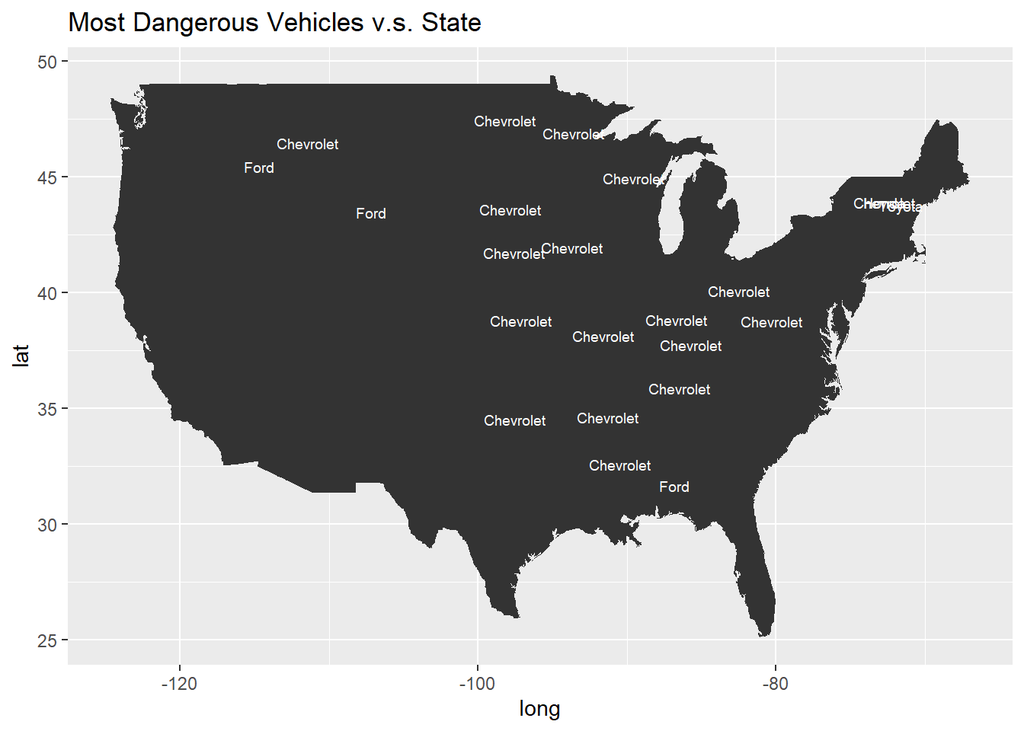

```r
#Reading data
usa <- readxl::read_xlsx("FRPP_GLC_-_United_StATESaPRIL62021.xlsx")
states <- map_data('state')

#Cleaning data
usa <- usa %>% mutate(`State Code` = as.numeric(`State Code`)) %>%
         mutate(`State Name` = tolower(`State Name`))

#Finding dangerous vehicles per state
usa2 <- usa %>% left_join(q3, by = c("State Code" = "STATE")) %>%
         select(`State Name`, `State Code`, MAKE, Accidents) %>%
         mutate(MAKE = as.factor(MAKE)) %>%
         unique()

states2 <- states %>%
      left_join(usa2 %>% select("MAKE", "State Name"), by = c("region" = "State Name"))

#Creating the map
usa3 <- states2 %>% group_by(region, MAKE) %>%
         summarize(long = mean(long), lat = mean(lat))

usa3$MAKE <- factor(usa3$MAKE, levels = c(12, 20, 37, 49), labels = c("Ford", "Chevrolet", "Honda", "Toyota"))

q4_map <- states %>% group_by(region)
q4_map %>% ggplot(aes(x = long, y = lat)) +
         geom_polygon(aes(group = group)) +
         geom_text(aes(label = MAKE), color = 'white', size = 2.5, data = usa3) +
         ggtitle("Most Dangerous Vehicles v.s. State")
```

**5. Join the accident and person table (work out which variable(s) to use)**

```r
acc_person <- accident %>% left_join(person, by = c("STATE", "COUNTY", "DAY", "MONTH", "HOUR", "MINUTE"))
```

**6. Tally the number of accidents by day of the week (DAY_WEEK), hour of the day (HOUR) and gender (SEX). Visualize the results and explain what you find.**

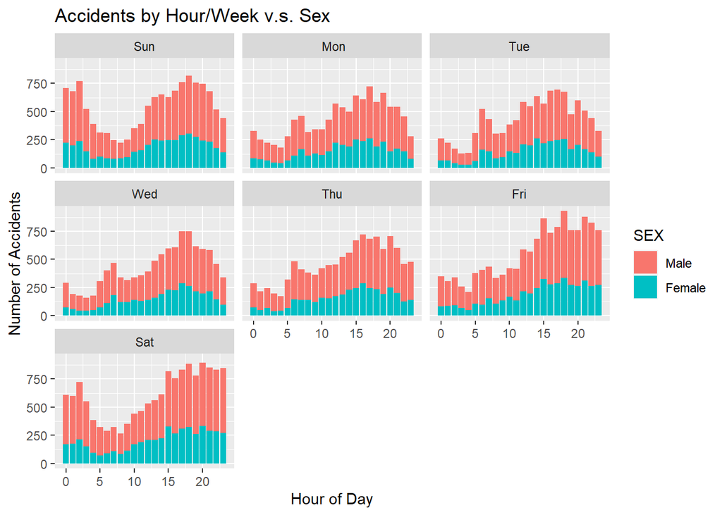

```r
acc_person$DAY_WEEK <- factor(acc_person$DAY_WEEK, labels = c("Sun"," Mon", "Tue", "Wed", "Thu", "Fri", "Sat"))
acc_person$SEX <- factor(acc_person$SEX, levels = c("1", "2"), labels = c("Male", "Female"))

q6 <- acc_person %>%
         filter(HOUR < 24) %>%
         group_by(DAY_WEEK, HOUR, SEX) %>%
         summarise(Accidents = n()) %>%
         drop_na()

q6 %>% ggplot(aes(x = HOUR, y = Accidents, fill = SEX)) + geom_bar(stat = 'identity') + facet_wrap(~DAY_WEEK) +
         ggtitle("Accidents by Hour/Week v.s. Sex") + xlab("Hour of Day") + ylab("Number of Accidents")
```

I decided to use facet wrap and stacked bar charts to represent all variables needed, Accidents, Hour, and Sex. I made sure to rename the factor labels from numbers to words so the data is more obvious.

**7. Now plot a choropleth map of the number of deaths on a county level. Also explain what you find.**

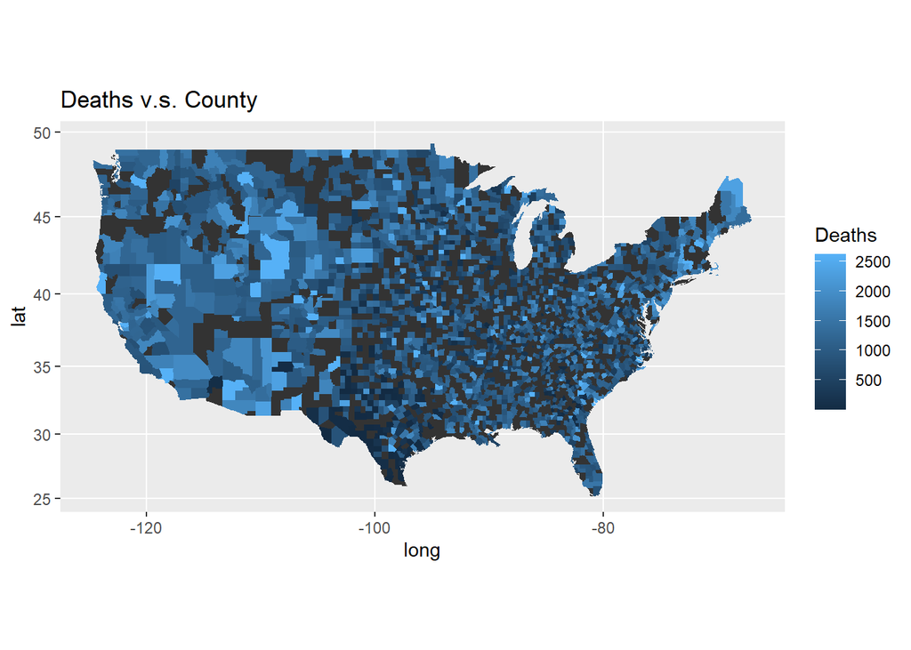

```r
#Reading and cleaning data
counties <- map_data('county')
usa <- usa %>% mutate(`County Code` = as.numeric(`County Code`)) %>%
         mutate(`County Name` = tolower(`County Name`))

#Making map
deaths <- acc_person %>%
         group_by(COUNTY) %>%
         summarise(Deaths = sum(FATALS)) %>%
         left_join(usa, by = c("COUNTY" = "County Code")) %>%
         select(COUNTY, Deaths, `County Name`) %>%
         unique()

deaths <- deaths %>% left_join(counties, by = c("County Name" = "subregion"))

counties %>% ggplot(aes(x = long, y = lat)) +
         geom_polygon(aes(group = group)) +
         geom_polygon(data = deaths, aes(x = long, y = lat, group = group, fill = Deaths)) +
         coord_map() + ggtitle("Deaths v.s. County")
```

From this map, I see that the west coast has a lot more deaths than the rest of the country (it seems that way). There’s a lot of counties that have zero to little deaths, most of them being in the midwest. This could be because they’re smaller and less populated states than the west coast, also, it could be because of counties being rural.

**8. Is summer or winter more dangerous? Does this depend on states? Explore and explain.**

```r
#Cleaning data up
acc_person$MONTH <- factor(acc_person$MONTH, labels = c("Jan", "Feb", "Mar", "Apr", "May", "Jun", "Jul", "Aug", "Sep", "Oct", "Nov", "Dec"))

summerMonths <- acc_person %>% filter(MONTH %in% c("Jun", "Jul", "Aug"))
winterMonths <- acc_person %>% filter(MONTH %in% c("Dec", "Jan", "Feb"))
```

```r
#Summer months 6-8
summer <- summerMonths %>%
         group_by(MONTH) %>%
         summarise(Fatalities = sum(FATALS))
summer
```

```
## # A tibble: 3 x 2
##   MONTH Fatalities
## * <fct>      <int>
## 1 Jun         8838
## 2 Jul         9568
## 3 Aug         7913
```

```r
#Winter months 12-2
winter <- winterMonths %>%
         group_by(MONTH) %>%
         summarise(Fatalities = sum(FATALS))
winter
```

```
## # A tibble: 3 x 2
##   MONTH Fatalities
## * <fct>      <int>
## 1 Jan         7338
## 2 Feb         6437
## 3 Dec         8164
```

I measured the months being dangerous by how many fatalities there were. FATALS were taken from the count of people who had INJ_SEV == 4 (according to the FARS manual). Overall, it looks like Summer had more fatalities than Winter, which surprised me since Winter was a bit more slicker. After thinking about it, it made sense that Summer had more since a lot of people had school off and was going out more because of the weather.

```r
summerMonths <- summerMonths %>% select(STATE, MONTH, FATALS)
winterMonths <- winterMonths %>% select(STATE, MONTH, FATALS)

#States in Summer
summerStates <- summerMonths %>%
         group_by(STATE) %>%
         summarise(sFatalities = sum(FATALS)) %>%
         arrange(desc(sFatalities))

#States in Winter
winterStates <- winterMonths %>%
         group_by(STATE) %>%
         summarise(wFatalities = sum(FATALS)) %>%
         arrange(desc(wFatalities))

#Had to do separate commands because I kept getting vector memory error
acc <- left_join(summerStates, winterStates, by = c("STATE" = "STATE"))
acc <- acc %>% left_join(usa, by = c("STATE" = "State Code"))
acc <- acc %>% left_join(states, by = c("State Name" = "region")) %>% select(`State Name`, sFatalities, wFatalities)
acc <- acc %>% unique()

#Shows states that get more accidents in the summer than winter
more_summer_acc <- acc %>% group_by(`State Name`) %>%
         summarise(summerAcc = sFatalities - wFatalities) %>%
         filter(summerAcc > 0) %>%
         arrange(desc(summerAcc))
more_summer_acc
```

```
## # A tibble: 40 x 2
##    `State Name` summerAcc
##    <chr>            <int>
##  1 indiana            378
##  2 california         321
##  3 texas              292
##  4 illinois           290
##  5 ohio               276
##  6 colorado           267
##  7 new mexico         235
##  8 georgia            216
##  9 new york           177
## 10 michigan           175
## # ... with 30 more rows
```

```r
#Shows states that get more accidents in winter than summer
more_winter_acc <- acc %>% group_by(`State Name`) %>%
         summarise(winterAcc = wFatalities - sFatalities) %>%
         filter(winterAcc > 0) %>%
         arrange(desc(winterAcc))
more_winter_acc
```

```
## # A tibble: 11 x 2
##    `State Name`   winterAcc
##    <chr>              <int>
##  1 florida              269
##  2 nevada               118
##  3 north carolina       110
##  4 south carolina        86
##  5 arizona               83
##  6 hawaii                36
##  7 louisiana             21
##  8 alaska                11
##  9 mississippi           11
## 10 new hampshire          7
## 11 delaware               4
```